# Data Preparation with Case 31

IC10-2-1 | Employees Federal Credit Union (EFCU) Member Opinion Survey

Author

Julieta Diaz

Published

October 26, 2026

# Overview

This report prepares the raw SPSS data from **Case 31: Employees Federal Credit Union** for analysis in R. Following the M08 data preparation procedure, I:

1. give each respondent an ID,
2. check and fix variable names, variable labels, and value labels,
3. assign the correct **scale of measurement** to each variable,
4. handle missing and “no answer / no opinion” codes,
5. reverse code questions where a higher number meant a *lower* amount of the concept,
6. run frequencies to check for errors and outliers,
7. run **reliability** and **factor analysis** on each multi-item measure, and
8. create a **composite index** for each construct.

**NoteData and questionnaire**

The raw data file is `data/Case 31 Data_efcu_1.sav` (SPSS format). Questions 1, 2, 28, 29, 35, 36, 39, and 40 are not in the file. Questions 1 and 2 were left out by the credit union because they are sensitive, and the others are open-ended. Every decision below was checked against the questionnaire (Case Exhibit 31.1) and the coding guide (Case Exhibit 31.2).

# 1 Load Packages

```r
# install.packages(c("tidyverse", "haven", "labelled", "psych"))  # run once if needed
library(tidyverse)  # data wrangling (dplyr, tidyr, ggplot2)
library(haven)      # read SPSS .sav files
library(labelled)   # work with variable and value labels
library(psych)      # reliability (alpha) and factor analysis
```

# 2 Import the Raw Data

```r
raw <- read_sav("data/Case 31 Data_efcu_1.sav")
dim(raw)
```

```
[1] 128  34
```

The raw file has **128 respondents** and **34 variables**.

## 2.1 Data Dictionary (Before Cleaning)

`look_for()` from the **labelled** package builds a data dictionary showing each variable’s name, label, and value labels.

```r
look_for(raw) |>
  convert_list_columns_to_character() |>
  select(pos, variable, label, value_labels)
```

| pos | variable | label | value_labels |
| --- | --- | --- | --- |
| 1 | q3 | Employees are Courteous | [1] Strongly Disagree; [5] Strongly Agree |
| 2 | q4 | employees are helpful | [1] Strongly Disagree; [5] Strongly Agree |
| 3 | q5 | employees are professional | [1] Strongly Disagree; [5] Strongly Agree |
| 4 | q6 | employees are available | [1] Strongly Disagree; [5] Strongly Agree |
| 5 | q7 | savings rates | [1] Very High; [2] High; [3] Average; [4] Low; [5] Very Low; [6] No Opinion |
| 6 | q8 | statement frequency | [1] Very High; [2] High; [3] Average; [4] Low; [5] Very Low; [6] No Opinion |
| 7 | q9 | statement frequency | [1] Too Often; [2] Very Often; [3] About Right; [4] Not Often Enough; [5] Never |
| 8 | q10 | statement accuracy | [1] Excellent; [2] Good; [3] Fair; [4] Poor |
| 9 | q11 | statement understandable | [1] Yes; [2] No |
| 10 | q12 | Account Confidential | [1] Yes; [2] No |
| 11 | q13 | regular share account | [1] Aware and Have Used; [2] Aware but Have Not Used |
| 12 | q14 | special subaccounts | [1] Aware and Have Used; [2] Aware but Have Not Used |
| 13 | q15 | Christmas club account | [1] Aware and Have Used; [2] Aware but Have Not Used |
| 14 | q16 | IRA | [1] Aware and Have Used; [2] Aware but Have Not Used |
| 15 | q17 | Master credit card | [1] Aware and Have Used; [2] Aware but Have Not Used |
| 16 | q18 | signature loans | [1] Aware and Have Used; [2] Aware but Have Not Used |
| 17 | q19 | new car loans | [1] Aware and Have Used; [2] Aware but Have Not Used |
| 18 | q20 | late model car loans | [1] Aware and Have Used; [2] Aware but Have Not Used |
| 19 | q21 | older model car loans | [1] Aware and Have Used; [2] Aware but Have Not Used |
| 20 | q22 | household goods loans | [1] Aware and Have Used; [2] Aware but Have Not Used |
| 21 | q23 | recreational loans | [1] Aware and Have Used; [2] Aware but Have Not Used |
| 22 | q24 | share collateralized loan | [1] Aware and Have Used; [2] Aware but Have Not Used |
| 23 | q25 | IRA loans | [1] Aware and Have Used; [2] Aware but Have Not Used |
| 24 | q26 | line of credit loans | [1] Aware and Have Used; [2] Aware but Have Not Used |
| 25 | q27 | currently have loan | [1] Yes; [2] No |
| 26 | q30 | CU rates lower | [1] Strongly Disagree; [5] Strongly Agree |
| 27 | q31 | CU confidential | [1] Strongly Disagree; [5] Strongly Agree |
| 28 | q32 | CU is prompt | [1] Strongly Disagree; [5] Strongly Agree |
| 29 | q33 | CU meets needs of members | [1] Strongly Disagree; [5] Strongly Agree |
| 30 | q34 | CU loan applications simple | [1] Strongly Disagree; [5] Strongly Agree |
| 31 | q37 | overall rating | [1] Excellent; [2] Good; [3] Average; [4] Poor; [5] Very Poor; [6] No Opinion |
| 32 | OverallEmployeePerformace | NA |  |
| 33 | q38 | headquarter | [1] yes; [2] no |
| 34 | employeeperformance | NA |  |

**WarningProblems found in the raw data**

- **No respondent ID**, so individual cases cannot be referenced.
- **`q8` has the wrong variable label.** It reads “statement frequency” (a copy of `q9`), but Question 8 asks about the **rates charged to borrow funds**.
- **Incomplete value labels.** Q3 to Q6 and Q30 to Q34 only label 1 and 5; Q13 to Q26 are missing the label for 3 (“Unaware of Service”); Q12 has a value of 3 (“no answer”) with no label.
- **`q12` uses 3 for “no answer”** (22 respondents), which must be treated as missing, not as a real answer.
- **Two duplicate composite columns** (`OverallEmployeePerformace` and `employeeperformance`) are identical and unlabeled. I drop them and rebuild the composite myself so the process is documented.
- **Reverse-coded items:** in Q7, Q8, Q9, Q10, Q13 to Q26, and Q37, a *lower* number means *more* of the concept (for example, 1 = “Very High”).

```r
# Confirm the two prebuilt composite columns are identical
all.equal(as.numeric(raw$OverallEmployeePerformace), as.numeric(raw$employeeperformance))
```

```
[1] TRUE
```

# 3 Basic Cleaning

## 3.1 Respondent ID and Duplicate Columns

```r
efcu <- raw |>
  mutate(id = row_number(), .before = 1) |>
  select(-OverallEmployeePerformace, -employeeperformance)
```

## 3.2 Variable Labels

I rewrite every variable label to match the wording on the questionnaire. This also fixes the wrong label on `q8`.

```r
efcu <- efcu |>
  set_variable_labels(
    id  = "Respondent ID",
    q3  = "Q3. CU employees are courteous",
    q4  = "Q4. CU employees are helpful",
    q5  = "Q5. CU employees are professional",
    q6  = "Q6. CU employees are always available",
    q7  = "Q7. Rates CU pays on share (savings) accounts",
    q8  = "Q8. Rates CU charges members to borrow funds",
    q9  = "Q9. How often you receive a financial statement",
    q10 = "Q10. Accuracy of statements",
    q11 = "Q11. Statements are easy to understand",
    q12 = "Q12. CU keeps account information confidential",
    q13 = "Q13. Awareness: regular share accounts",
    q14 = "Q14. Awareness: special subaccounts",
    q15 = "Q15. Awareness: Christmas club accounts",
    q16 = "Q16. Awareness: individual retirement accounts",
    q17 = "Q17. Awareness: MasterCard credit cards",
    q18 = "Q18. Awareness: signature loans",
    q19 = "Q19. Awareness: new car loans",
    q20 = "Q20. Awareness: late model car loans",
    q21 = "Q21. Awareness: older model car loans",
    q22 = "Q22. Awareness: household goods/appliance loans",
    q23 = "Q23. Awareness: recreational loans",
    q24 = "Q24. Awareness: share collateralized loans",
    q25 = "Q25. Awareness: IRA loans",
    q26 = "Q26. Awareness: line of credit loans",
    q27 = "Q27. Currently have a loan with the CU",
    q30 = "Q30. CU loan rates are lower than other institutions",
    q31 = "Q31. CU personnel keep my financial information confidential",
    q32 = "Q32. CU is prompt in processing loan applications",
    q33 = "Q33. CU services meet the needs of its members",
    q34 = "Q34. CU loan applications are simple and easy",
    q37 = "Q37. Overall, how well the CU is managed and operated",
    q38 = "Q38. Live in the headquarters area"
  )
```

## 3.3 Value Labels

The labels follow the coding guide in Case Exhibit 31.2. I complete the missing labels so every value has a meaning.

```r
agree_5 <- c("Strongly disagree" = 1, "Disagree" = 2, "Uncertain" = 3,
             "Agree" = 4, "Strongly agree" = 5)
yes_no  <- c("Yes" = 1, "No" = 2)
aware_3 <- c("Aware and have used" = 1, "Aware but have not used" = 2,
             "Unaware of service" = 3)

# Helper: apply a set of value labels while keeping each variable label
add_labels <- function(x, labels) {
  labelled(as.numeric(x), labels = labels, label = var_label(x))
}

efcu <- efcu |>
  mutate(
    across(c(q3:q6, q30:q34), ~ add_labels(.x, agree_5)),
    across(q7:q8, ~ add_labels(.x, c("Very high" = 1, "High" = 2, "Average" = 3,
                                     "Low" = 4, "Very low" = 5, "No opinion" = 6))),
    q9  = add_labels(q9, c("Too often" = 1, "Very often" = 2, "About right" = 3,
                           "Not often enough" = 4, "Never" = 5)),
    q10 = add_labels(q10, c("Excellent" = 1, "Good" = 2, "Fair" = 3, "Poor" = 4)),
    across(c(q11, q27, q38), ~ add_labels(.x, yes_no)),
    q12 = add_labels(q12, c(yes_no, "No answer" = 3)),
    across(q13:q26, ~ add_labels(.x, aware_3)),
    q37 = add_labels(q37, c("Excellent" = 1, "Good" = 2, "Average" = 3,
                            "Poor" = 4, "Very poor" = 5, "No opinion" = 6))
  )
```

## 3.4 Missing Values and Special Codes

“No opinion” (6) on Q7, Q8, and Q37 and “No answer” (3) on Q12 are not points on the scale, so they become `NA`. In this file, “No opinion” on Q7, Q8, and Q37 was already left blank; the code below makes the rule explicit and catches Q12.

```r
efcu <- efcu |>
  mutate(
    across(c(q7, q8, q37), ~ replace(.x, .x == 6, NA)),
    q12 = replace(q12, q12 == 3, NA)
  )

# Missing values per variable (only variables with any missing shown)
efcu |>
  summarise(across(everything(), ~ sum(is.na(.x)))) |>
  pivot_longer(everything(), names_to = "variable", values_to = "n_missing") |>
  filter(n_missing > 0)
```

| variable | n_missing |
| --- | --- |
| q7 | 10 |
| q8 | 21 |
| q12 | 22 |
| q37 | 7 |

# 4 Scales of Measurement

Every variable gets a scale of measurement based on what its numbers mean. In R, the scale is expressed through the variable type: **nominal** variables become unordered factors, **ordinal** variables become ordered factors, and **interval** variables stay numeric so they can be averaged.

Scale of measurement for each variable

| Variables | Response format | Scale | R type |
| --- | --- | --- | --- |
| `id` | Respondent number | Nominal | integer (identifier only) |
| Q3 to Q6, Q30 to Q34 | 5-point Likert, strongly disagree to strongly agree | Interval | numeric |
| Q7, Q8 | Very high to very low | Interval (rating scale, after reverse coding) | numeric |
| Q9 | Too often to never | Ordinal | numeric for recoding, ordered factor for reporting |
| Q10 | Excellent to poor | Interval (rating scale, after reverse coding) | numeric |
| Q37 | Excellent to very poor | Interval (rating scale, after reverse coding) | numeric |
| Q13 to Q26 | Aware and used / aware not used / unaware | Ordinal | numeric for the awareness index |
| Q11, Q12, Q27, Q38 | Yes / No | Nominal | factor |

**TipWhy Likert items are treated as interval**

A Likert item has the properties of an ordinal scale (5 is more agreement than 4), and researchers assume the distance between each point is equal. That equal-interval assumption is what lets us **average** items into a composite index.

# 5 Reverse Coding

A higher number should always mean **more** of the concept. In these items the coding guide runs the other way, so I create a new reversed variable with an `r` suffix and keep the original. The formula is **(highest code + 1) minus the original value**.

Reverse coding plan

| Item(s) | Original coding | Formula | New coding |
| --- | --- | --- | --- |
| Q7, Q8 | 1 = very high, 5 = very low | `6 - x` (after “no opinion” set to `NA`) | 1 = very low, 5 = very high |
| Q9 | 1 = too often, 5 = never | `6 - x` | 1 = never, 5 = too often |
| Q10 | 1 = excellent, 4 = poor | `5 - x` | 1 = poor, 4 = excellent |
| Q13 to Q26 | 1 = aware and used, 3 = unaware | `4 - x` | 1 = unaware, 3 = aware and used |
| Q37 | 1 = excellent, 5 = very poor | `6 - x` (after “no opinion” set to `NA`) | 1 = very poor, 5 = excellent |

```r
efcu <- efcu |>
  mutate(
    across(c(q7, q8, q9, q37), ~ 6 - as.numeric(.x), .names = "{.col}r"),
    q10r = 5 - as.numeric(q10),
    across(q13:q26, ~ 4 - as.numeric(.x), .names = "{.col}r")
  )
```

The new variables get their own labels so the direction is clear.

```r
aware_r <- c("Unaware of service" = 1, "Aware but have not used" = 2,
             "Aware and have used" = 3)

efcu <- efcu |>
  mutate(
    across(q7r:q8r, ~ add_labels(.x, c("Very low" = 1, "Low" = 2, "Average" = 3,
                                       "High" = 4, "Very high" = 5))),
    q9r  = add_labels(q9r, c("Never" = 1, "Not often enough" = 2, "About right" = 3,
                             "Very often" = 4, "Too often" = 5)),
    q37r = add_labels(q37r, c("Very poor" = 1, "Poor" = 2, "Average" = 3,
                              "Good" = 4, "Excellent" = 5)),
    q10r = add_labels(q10r, c("Poor" = 1, "Fair" = 2, "Good" = 3, "Excellent" = 4)),
    across(q13r:q26r, ~ add_labels(.x, aware_r))
  )

# Copy each original label and add "(reversed)"
for (v in c("q7", "q8", "q9", "q10", paste0("q", 13:26), "q37")) {
  var_label(efcu[[paste0(v, "r")]]) <- paste(var_label(efcu[[v]]), "(reversed)")
}
```

## 5.1 Check the Recodes

A cross-tab of the original and reversed values confirms each value flipped correctly.

```r
efcu |> count(q7, q7r)
```

| q7 | q7r | n |
| --- | --- | --- |
| 2 | 4 | 22 |
| 3 | 3 | 83 |
| 4 | 2 | 12 |
| 5 | 1 | 1 |
| NA | NA | 10 |

```r
efcu |> count(q10, q10r)
```

| q10 | q10r | n |
| --- | --- | --- |
| 1 | 4 | 68 |
| 2 | 3 | 54 |
| 3 | 2 | 4 |
| 4 | 1 | 2 |

```r
efcu |> count(q13, q13r)
```

| q13 | q13r | n |
| --- | --- | --- |
| 1 | 3 | 13 |
| 2 | 2 | 32 |
| 3 | 1 | 83 |

```r
efcu |> count(q37, q37r)
```

| q37 | q37r | n |
| --- | --- | --- |
| 1 | 5 | 31 |
| 2 | 4 | 71 |
| 3 | 3 | 16 |
| 4 | 2 | 2 |
| 5 | 1 | 1 |
| NA | NA | 7 |

# 6 Frequencies and Error Checks

## 6.1 Out-of-Range Values

Every value should fall inside the range allowed by the questionnaire. Any count above zero would signal a data entry error.

```r
ranges <- tribble(
  ~vars,                                   ~min, ~max,
  c(paste0("q", 3:6), paste0("q", 30:34)), 1,    5,
  c("q7", "q8", "q9", "q37"),              1,    5,
  "q10",                                   1,    4,
  paste0("q", 13:26),                      1,    3,
  c("q11", "q12", "q27", "q38"),           1,    2
)

ranges |>
  rowwise() |>
  mutate(
    n_out_of_range = sum(sapply(vars, \(v) {
      x <- as.numeric(efcu[[v]])
      sum(x < min | x > max, na.rm = TRUE)
    })),
    vars = paste(vars, collapse = ", ")
  ) |>
  ungroup()
```

| vars | min | max | n_out_of_range |
| --- | --- | --- | --- |
| q3, q4, q5, q6, q30, q31, q32, q33, q34 | 1 | 5 | 0 |
| q7, q8, q9, q37 | 1 | 5 | 0 |
| q10 | 1 | 4 | 0 |
| q13, q14, q15, q16, q17, q18, q19, q20, q21, q22, q23, q24, q25, q26 | 1 | 3 | 0 |
| q11, q12, q27, q38 | 1 | 2 | 0 |

All values are within range, so there are no impossible values or outliers to fix.

## 6.2 Straight-Lining Check

The procedure asks whether anyone answered “all 5’s.” I check for respondents who gave the identical answer to every agreement item (Q3 to Q6 and Q30 to Q34).

```r
efcu |>
  mutate(n_unique = apply(across(c(q3:q6, q30:q34), as.numeric), 1,
                          \(r) length(unique(r)))) |>
  filter(n_unique == 1) |>
  select(id, q3:q6, q30:q34)
```

| id | q3 | q4 | q5 | q6 | q30 | q31 | q32 | q33 | q34 |
| --- | --- | --- | --- | --- | --- | --- | --- | --- | --- |
| 1 | 4 | 4 | 4 | 4 | 4 | 4 | 4 | 4 | 4 |
| 5 | 4 | 4 | 4 | 4 | 4 | 4 | 4 | 4 | 4 |
| 6 | 4 | 4 | 4 | 4 | 4 | 4 | 4 | 4 | 4 |
| 10 | 4 | 4 | 4 | 4 | 4 | 4 | 4 | 4 | 4 |
| 62 | 3 | 3 | 3 | 3 | 3 | 3 | 3 | 3 | 3 |
| 70 | 4 | 4 | 4 | 4 | 4 | 4 | 4 | 4 | 4 |
| 77 | 3 | 3 | 3 | 3 | 3 | 3 | 3 | 3 | 3 |
| 79 | 4 | 4 | 4 | 4 | 4 | 4 | 4 | 4 | 4 |

Eight respondents (IDs 1, 5, 6, 10, 62, 70, 77, and 79) gave the same answer to all nine agreement items. None of them answered all 5’s; each chose “Agree” (4) or “Uncertain” (3) throughout. A consistent mid-scale pattern is believable for a satisfied but not enthusiastic member, so I **flag but keep** these cases rather than deleting them.

## 6.3 Frequency Tables

```r
# Frequency table with value labels and valid percentages
freq <- function(data, var) {
  data |>
    mutate({{ var }} := as_factor({{ var }})) |>
    count({{ var }}) |>
    mutate(percent = round(100 * n / sum(n), 1))
}
```

**Employees (Q3 to Q6)**

```r
efcu |>
  select(q3:q6) |>
  pivot_longer(everything(), names_to = "item", values_to = "value") |>
  count(item, value) |>
  pivot_wider(names_from = value, values_from = n, values_fill = 0,
              names_sort = TRUE)
```

| item | 2 | 3 | 4 | 5 |
| --- | --- | --- | --- | --- |
| q3 | 0 | 13 | 57 | 58 |
| q4 | 1 | 14 | 57 | 56 |
| q5 | 0 | 23 | 72 | 33 |
| q6 | 4 | 23 | 60 | 41 |

Most members agree or strongly agree that employees are courteous, helpful, professional, and available. Nobody strongly disagreed with any of the four.

**Rates (Q7r, Q8r)**

```r
freq(efcu, q7r)
```

| q7r | n | percent |
| --- | --- | --- |
| Very low | 1 | 0.8 |
| Low | 12 | 9.4 |
| Average | 83 | 64.8 |
| High | 22 | 17.2 |
| NA | 10 | 7.8 |

```r
freq(efcu, q8r)
```

| q8r | n | percent |
| --- | --- | --- |
| Very low | 1 | 0.8 |
| Low | 17 | 13.3 |
| Average | 59 | 46.1 |
| High | 26 | 20.3 |
| Very high | 4 | 3.1 |
| NA | 21 | 16.4 |

**Statements (Q9 to Q12)**

```r
freq(efcu, q9)
```

| q9 | n | percent |
| --- | --- | --- |
| About right | 99 | 77.3 |
| Not often enough | 29 | 22.7 |

```r
freq(efcu, q10r)
```

| q10r | n | percent |
| --- | --- | --- |
| Poor | 2 | 1.6 |
| Fair | 4 | 3.1 |
| Good | 54 | 42.2 |
| Excellent | 68 | 53.1 |

```r
freq(efcu, q11)
```

| q11 | n | percent |
| --- | --- | --- |
| Yes | 125 | 97.7 |
| No | 3 | 2.3 |

```r
freq(efcu, q12)
```

| q12 | n | percent |
| --- | --- | --- |
| Yes | 74 | 57.8 |
| No | 32 | 25.0 |
| NA | 22 | 17.2 |

**Overall (Q37r, Q38)**

```r
freq(efcu, q37r)
```

| q37r | n | percent |
| --- | --- | --- |
| Very poor | 1 | 0.8 |
| Poor | 2 | 1.6 |
| Average | 16 | 12.5 |
| Good | 71 | 55.5 |
| Excellent | 31 | 24.2 |
| NA | 7 | 5.5 |

```r
freq(efcu, q38)
```

| q38 | n | percent |
| --- | --- | --- |
| Yes | 57 | 44.5 |
| No | 71 | 55.5 |

# 7 Multi-Item Measures

The questionnaire has three groups of items that measure one construct together:

Multi-item measures

| Construct | Items | Name of composite |
| --- | --- | --- |
| Attitude toward CU employees | Q3, Q4, Q5, Q6 | `att_employee` |
| Attitude toward CU operations and lending | Q30, Q31, Q32, Q33, Q34 | `att_cu` |
| Awareness of CU services | Q13r to Q26r | `awareness` |

For each one, I run a **reliability analysis** (Cronbach’s alpha) and an **exploratory factor analysis** before averaging the items. An alpha of **0.70 or higher** is the usual standard for acceptable reliability, and a one-factor solution with loadings of about **0.40 or higher** supports treating the items as one construct.

## 7.1 Attitude Toward Employees (Q3 to Q6)

```r
emp_items <- efcu |> select(q3:q6) |> mutate(across(everything(), as.numeric))
alpha_emp <- psych::alpha(emp_items)
alpha_emp$total |> select(raw_alpha, std.alpha, average_r) |> round(3)
```

|  | raw_alpha | std.alpha | average_r |
| --- | --- | --- | --- |
|  | 0.866 | 0.869 | 0.624 |

```r
alpha_emp$alpha.drop |> select(raw_alpha) |> round(3)
```

|  | raw_alpha |
| --- | --- |
| q3 | 0.852 |
| q4 | 0.785 |
| q5 | 0.824 |
| q6 | 0.853 |

```r
fa_emp <- fa(emp_items, nfactors = 1, fm = "pa")
print(fa_emp$loadings, cutoff = 0)
```

```
Loadings:
   PA1
q3 0.723
q4 0.922
q5 0.793
q6 0.729

                 PA1
SS loadings    2.532
Proportion Var 0.633
```

## 7.2 Attitude Toward CU Operations (Q30 to Q34)

```r
cu_items <- efcu |> select(q30:q34) |> mutate(across(everything(), as.numeric))
alpha_cu <- psych::alpha(cu_items)
alpha_cu$total |> select(raw_alpha, std.alpha, average_r) |> round(3)
```

|  | raw_alpha | std.alpha | average_r |
| --- | --- | --- | --- |
|  | 0.539 | 0.536 | 0.188 |

```r
alpha_cu$alpha.drop |> select(raw_alpha) |> round(3)
```

|  | raw_alpha |
| --- | --- |
| q30 | 0.472 |
| q31 | 0.494 |
| q32 | 0.363 |
| q33 | 0.527 |
| q34 | 0.536 |

```r
fa_cu <- fa(cu_items, nfactors = 1, fm = "pa")
print(fa_cu$loadings, cutoff = 0)
```

```
Loadings:
    PA1
q30 0.404
q31 0.381
q32 0.780
q33 0.296
q34 0.354

                 PA1
SS loadings    1.130
Proportion Var 0.226
```

## 7.3 Awareness of Services (Q13r to Q26r)

```r
aware_items <- efcu |> select(q13r:q26r) |> mutate(across(everything(), as.numeric))
alpha_aware <- psych::alpha(aware_items, check.keys = FALSE)
alpha_aware$total |> select(raw_alpha, std.alpha, average_r) |> round(3)
```

|  | raw_alpha | std.alpha | average_r |
| --- | --- | --- | --- |
|  | 0.803 | 0.807 | 0.23 |

```r
alpha_aware$alpha.drop |> select(raw_alpha) |> round(3)
```

|  | raw_alpha |
| --- | --- |
| q13r | 0.792 |
| q14r | 0.790 |
| q15r | 0.781 |
| q16r | 0.800 |
| q17r | 0.789 |
| q18r | 0.794 |
| q19r | 0.795 |
| q20r | 0.792 |
| q21r | 0.785 |
| q22r | 0.794 |
| q23r | 0.783 |
| q24r | 0.786 |
| q25r | 0.796 |
| q26r | 0.789 |

```r
fa_aware <- fa(aware_items, nfactors = 1, fm = "pa")
print(fa_aware$loadings, cutoff = 0)
```

```
Loadings:
     PA1
q13r 0.452
q14r 0.482
q15r 0.584
q16r 0.379
q17r 0.513
q18r 0.435
q19r 0.423
q20r 0.460
q21r 0.545
q22r 0.439
q23r 0.578
q24r 0.535
q25r 0.385
q26r 0.507

                 PA1
SS loadings    3.279
Proportion Var 0.234
```

## 7.4 Reliability Summary

```r
tibble(
  construct = c("att_employee", "att_cu", "awareness"),
  items     = c("Q3 to Q6", "Q30 to Q34", "Q13r to Q26r"),
  n_items   = c(4, 5, 14),
  alpha     = c(alpha_emp$total$raw_alpha, alpha_cu$total$raw_alpha,
                alpha_aware$total$raw_alpha)
) |>
  mutate(alpha = round(alpha, 3),
         acceptable = if_else(alpha >= 0.70, "Yes", "Below 0.70"))
```

| construct | items | n_items | alpha | acceptable |
| --- | --- | --- | --- | --- |
| att_employee | Q3 to Q6 | 4 | 0.866 | Yes |
| att_cu | Q30 to Q34 | 5 | 0.539 | Below 0.70 |
| awareness | Q13r to Q26r | 14 | 0.803 | Yes |

**Interpretation.** Attitude toward employees (alpha = 0.87) and awareness of services (alpha = 0.80) both pass the 0.70 standard, and their items load together on a single factor (most loadings near or above 0.40), so they can be combined into composite indexes. No awareness item would raise alpha if dropped.

Attitude toward CU operations (alpha = 0.54) does **not** meet the standard. Dropping any single item does not fix it, and only Q32 (prompt loan processing) loads strongly on the factor. That makes sense from the questionnaire: Q30 to Q34 ask about different things (loan rates, confidentiality, speed, meeting needs, and simple applications), so they do not measure one underlying attitude. I still build `att_cu` to show the process, but it should be used with caution, and in later analysis these five items are better analyzed **one at a time**.

# 8 Composite Indexes

Each composite is the **row mean** of its items. `rowMeans(..., na.rm = TRUE)` keeps a respondent who skipped one item instead of dropping them.

```r
efcu <- efcu |>
  mutate(
    att_employee = rowMeans(across(q3:q6,     as.numeric), na.rm = TRUE),
    att_cu       = rowMeans(across(q30:q34,   as.numeric), na.rm = TRUE),
    awareness    = rowMeans(across(q13r:q26r, as.numeric), na.rm = TRUE)
  ) |>
  set_variable_labels(
    att_employee = "Attitude toward CU employees (mean of Q3 to Q6; 1 to 5)",
    att_cu       = "Attitude toward CU operations (mean of Q30 to Q34; 1 to 5)",
    awareness    = "Awareness of CU services (mean of Q13r to Q26r; 1 to 3)"
  )

efcu |>
  select(att_employee, att_cu, awareness) |>
  describe() |>
  select(n, mean, sd, min, max) |>
  round(2)
```

|  | n | mean | sd | min | max |
| --- | --- | --- | --- | --- | --- |
| att_employee | 128 | 4.21 | 0.59 | 2.75 | 5.00 |
| att_cu | 128 | 3.56 | 0.45 | 2.60 | 4.80 |
| awareness | 128 | 1.86 | 0.31 | 1.07 | 2.57 |

```r
# My att_employee matches the composite that came with the raw file
all.equal(as.numeric(efcu$att_employee), as.numeric(raw$employeeperformance))
```

```
[1] TRUE
```

The rebuilt `att_employee` index matches the unlabeled composite that came with the raw file exactly, which confirms that column was the mean of Q3 to Q6.

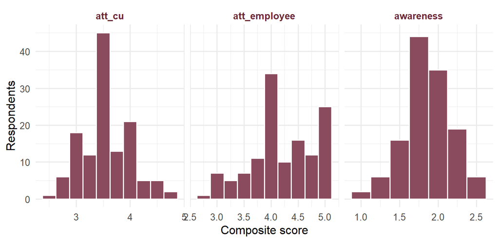

Figure 1: Distribution of the three composite indexes

```r
efcu |>
  select(att_employee, att_cu, awareness) |>
  pivot_longer(everything(), names_to = "index", values_to = "score") |>
  ggplot(aes(score)) +
  geom_histogram(binwidth = 0.25, fill = "#8A4B5E", color = "white") +
  facet_wrap(~ index, scales = "free_x") +
  labs(x = "Composite score", y = "Respondents") +
  theme_minimal(base_size = 12) +
  theme(strip.text = element_text(face = "bold", color = "#6B2737"))
```

# 9 Nominal Variables as Factors

Yes/no questions are nominal, so they become factors with their labels as the categories.

```r
efcu <- efcu |>
  mutate(across(c(q11, q12, q27, q38), as_factor, .names = "{.col}_f"))

efcu |> count(q38_f)
```

| q38_f | n |
| --- | --- |
| Yes | 57 |
| No | 71 |